# Missing Data

Junyan Yao

2020-01-22

## Outline of this article

1. Missing Data Mechanisms
2. Simple missing data fixes: LVCF, mean imputation, dummy variable methods
3. More complicated missing data fixes: Weighting, hotdecking, regression imputation
4. Building blocks and overview of multiple imputation, including regresion imputation with noise
5. More advanced imputation and other missing data methods

## Examining Patterns of Missing Data

### Cases:

- Univariate Nonresponse:

[figure not shown]

- Multivariate Two Patterns:

[figure not shown]

- Monotone:

[figure not shown]

- General:

[figure not shown]

** Notation and explanation Let R be the matrix of variables $R_{1}$, $R_{2}$,…,$R_{p}$, corresponding to variables in dataset, $Y_{1}$, $Y_{2}$, …,$Y_{p}$, that indicate whether a given value of the corresponding Y variable is observed(=1) or missing(=0)

## Missing Data Mechanisms:

### Simple missing data methods:

#### Methods that throw away data

- Complete cases (listwise deletion)

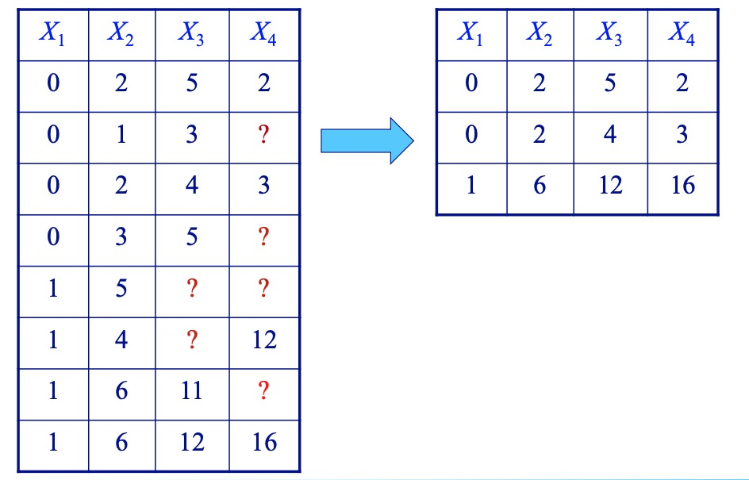

- Complete variables (available case)

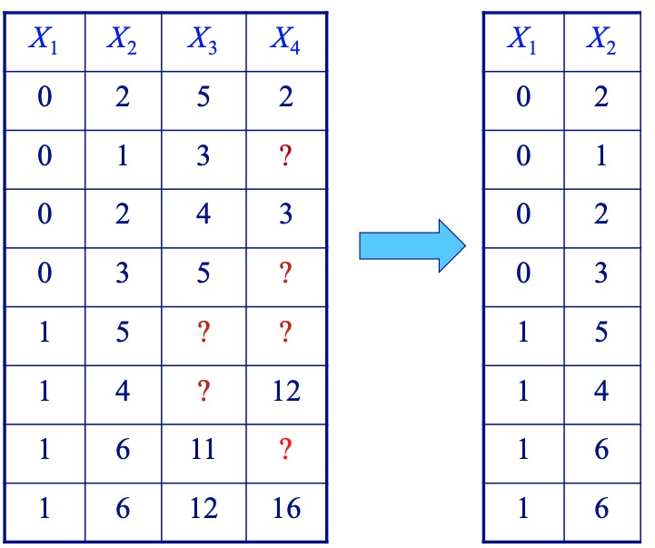

#### Methods that don’t throw away data

- Mean imputation

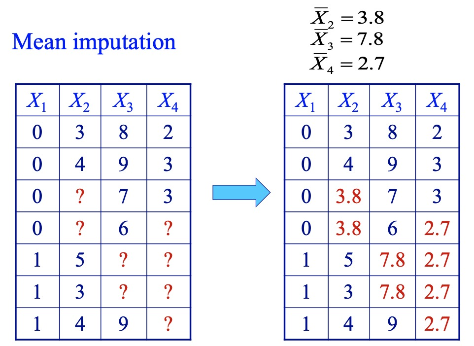

- Last value carried forward

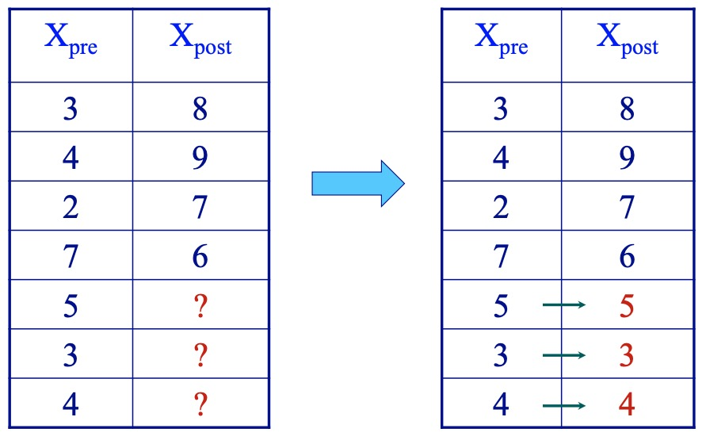

- Dummy variable method
  - For example, for each predictor variable with missing data, fills in missing values with 0 or the mean and then includes a new variable that is an indicator for missingness for the original variable with missing data.
- Reports from others
  - For example, we are missing data regarding the fathers of children in a dataset, we can probably fill these values in with mother’s report of the values.

### More complicated missing data methods

#### Methods that throw away data

- Non-response weighting
  - Suppose only one variable has missing data, we can build a model to predict whether a vlaue is observed using observed values from the other variables. Then use these predicted probabilities to create survey weights of the form $1/P(\frac{R_{i}}{X_{i}})$ to make the complete case sample representative of the full sample once again. Typically we normalize by multiplying the weights by the overall (marginal) probability of missingness, $P(R_{i})$. This way the weights will sum to the number of people left in the complete case sample.

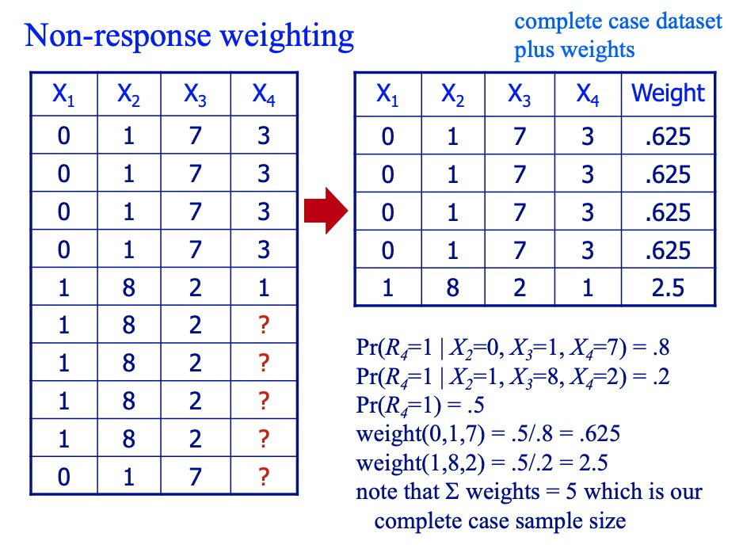

#### Methods that don’t throw away data

- Hotdecking
  - Replaces missing values using other values found in the dataset.For example, for each person with a missing value on variable Y, find another person who has all the same values (or close to the same values) on observed variables $X_{1}, X_{2},X_{3}...$, and use that person’s Y value.
- Regression imputation
  - Suppose only one variable has missing data, within the complete case sample, build a model that predicts the values of that variable.

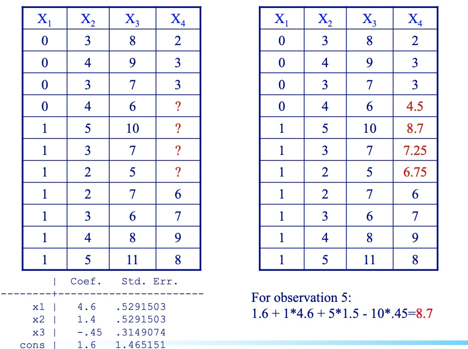

### Multiple regression imputation with noise

Multiple imputation uses observed data to impute missing values that reflect both sampling variability and model uncertainty. It creates several imputations for each missing value and thus creates several completed datasets.